# Overview

This is a basic analysis for crime dataset from seattle during summer 2014, which analyzes the incident types of crime and time pattern of crime occurrence during that time.

# Data

All datasets are from the course link: https://github.com/uwescience/datasci_course_materials/tree/master/assignment6 More can be seen in detail from READE.md file in that assignment.

# Code

I use Python with Pandas and matplotlib packages to do basic analysis.

# Data Overview

As you can see from below table, I imported all dataset from external file and show first 5 rows of that dataset. This dataset contains many attributes but not so dirty -- NaN just occurs in the col of Occurred Date Range End.

```python
# Imports

# pandas
import pandas as pd
from pandas import Series,DataFrame

# numpy, matplotlib, seaborn
import numpy as np
import matplotlib.pyplot as plt
import seaborn as sns
sns.set_style('whitegrid')
%matplotlib inline

# machine learning
# from sklearn.linear_model import LogisticRegression
# from sklearn.svm import SVC, LinearSVC
# from sklearn.ensemble import RandomForestClassifier
# from sklearn.neighbors import KNeighborsClassifier
# from sklearn.naive_bayes import GaussianNB

# get crime dataset
crime_df = pd.read_csv('./seattle_incidents_summer_2014.csv', low_memory=False)

# get a sense of dataset
crime_df.head()
```

|  | RMS CDW ID | General Offense Number | Offense Code | Offense Code Extension | Offense Type | Summary Offense Code | Summarized Offense Description | Date Reported | Occurred Date or Date Range Start | Occurred Date Range End | Hundred Block Location | District/Sector | Zone/Beat | Census Tract 2000 | Longitude | Latitude | Location | Month | Year |
| --- | --- | --- | --- | --- | --- | --- | --- | --- | --- | --- | --- | --- | --- | --- | --- | --- | --- | --- | --- |
| 0 | 483839 | 2015218538 | 2202 | 0 | BURGLARY-FORCE-RES | 2200 | BURGLARY | 06/28/2015 10:31:00 AM | 06/28/2014 10:31:00 AM | 06/28/2015 10:31:00 AM | 6XX BLOCK OF NW 74 ST | J | J2 | 2900.3013 | -122.364672 | 47.682524 | (47.68252427, -122.364671996) | 6 | 2014 |
| 1 | 481252 | 2015213067 | 2610 | 0 | FRAUD-IDENTITY THEFT | 2600 | FRAUD | 06/24/2015 11:09:00 AM | 06/01/2014 12:00:00 AM | 06/24/2015 11:09:00 AM | 23XX BLOCK OF 43 AV E | C | C2 | 6300.1004 | -122.277080 | 47.639901 | (47.639900761, -122.277080248) | 6 | 2014 |
| 2 | 481375 | 2015210301 | 2316 | 0 | THEFT-MAIL | 2300 | MAIL THEFT | 06/22/2015 09:22:00 AM | 08/31/2014 09:00:00 AM | NaN | 81XX BLOCK OF 11 AV SW | F | F3 | 11300.5013 | -122.349312 | 47.529232 | (47.529232299, -122.349312181) | 8 | 2014 |
| 3 | 481690 | 2015209327 | 2599 | 0 | COUNTERFEIT | 2500 | COUNTERFEIT | 06/21/2015 03:52:00 PM | 06/20/2014 01:38:00 PM | NaN | 6XX BLOCK OF PINE ST | M | M2 | 8200.1002 | -122.334818 | 47.612368 | (47.612368448, -122.334817763) | 6 | 2014 |
| 4 | 478198 | 2015207880 | 2399 | 3 | THEFT-OTH | 2300 | OTHER PROPERTY | 06/20/2015 11:59:00 AM | 06/01/2014 11:59:00 AM | 11/01/2014 12:00:00 PM | 77XX BLOCK OF SUNNYSIDE AV N | J | J3 | 2700.2015 | -122.329379 | 47.685960 | (47.685959879, -122.329378505) | 6 | 2014 |

In this basic analysis, most of the data are useless, hence I drop them for further study.

```python
# drop necessary cols for this analysis
crime_df = crime_df.drop(['General Offense Number', 'RMS CDW ID', 'Offense Code', 'Offense Code Extension', 'Summary Offense Code', 'Date Reported', 'Occurred Date Range End'], axis=1)
```

# Crime Types

First question is: what crime types are frequently happened during this period of time? As you can see from below graph, Car Powl is the most siginificant crime type in seattle.

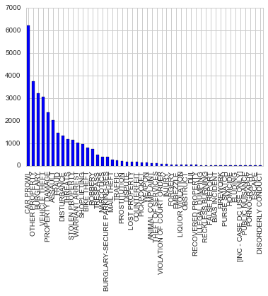

```python
crime_df['Summarized Offense Description'].value_counts().plot(kind='bar')
```

Next, we'd like to know what is the place most crimes happened in Seattle? From below graph, we can see district of M contains most crimes. But the difference among those districts are not very significant. Expect 99, which seems like an outlier, the place with lowest crime number is district O.

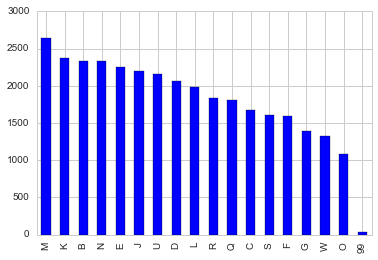

```python
crime_df['District/Sector'].value_counts().plot(kind='bar')
```

Furthermore, we want to know in what areas or neighborhoods are robberies or thefts most common. As you can see from below graph, districts of J and B are the two top areas robberies or thefts most common, which is different from the general pattern.

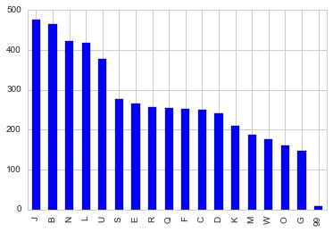

```python
crime_df.loc[crime_df['Summarized Offense Description'].isin(['VEHICLE THEFT','BIKE THEFT','ROBBERY','MAIL THEFT'])]['District/Sector'].value_counts().plot(kind='bar')
```

# Time Pattern

Specifically, we also need to know during what periods of the day are robberies most common. I put the Occurred Date or Date Range Start col as pandas.DateTimeIndex and separate it into date and time for further study.

```python
crime_df['Occurred Date or Date Range Start'] = pd.to_datetime(crime_df['Occurred Date or Date Range Start'])
```

```python
crime_df = crime_df.set_index('Occurred Date or Date Range Start')
```

```python
crime_df['time'] = crime_df.index.hour
```

```python
crime_df.head()
```

| Occurred Date or Date Range Start | Offense Type | Summarized Offense Description | Hundred Block Location | District/Sector | Zone/Beat | Census Tract 2000 | Longitude | Latitude | Location | Month | Year | time |
| --- | --- | --- | --- | --- | --- | --- | --- | --- | --- | --- | --- | --- |
| 2014-06-28 10:31:00 | BURGLARY-FORCE-RES | BURGLARY | 6XX BLOCK OF NW 74 ST | J | J2 | 2900.3013 | -122.364672 | 47.682524 | (47.68252427, -122.364671996) | 6 | 2014 | 10 |
| 2014-06-01 00:00:00 | FRAUD-IDENTITY THEFT | FRAUD | 23XX BLOCK OF 43 AV E | C | C2 | 6300.1004 | -122.277080 | 47.639901 | (47.639900761, -122.277080248) | 6 | 2014 | 0 |
| 2014-08-31 09:00:00 | THEFT-MAIL | MAIL THEFT | 81XX BLOCK OF 11 AV SW | F | F3 | 11300.5013 | -122.349312 | 47.529232 | (47.529232299, -122.349312181) | 8 | 2014 | 9 |
| 2014-06-20 13:38:00 | COUNTERFEIT | COUNTERFEIT | 6XX BLOCK OF PINE ST | M | M2 | 8200.1002 | -122.334818 | 47.612368 | (47.612368448, -122.334817763) | 6 | 2014 | 13 |
| 2014-06-01 11:59:00 | THEFT-OTH | OTHER PROPERTY | 77XX BLOCK OF SUNNYSIDE AV N | J | J3 | 2700.2015 | -122.329379 | 47.685960 | (47.685959879, -122.329378505) | 6 | 2014 | 11 |

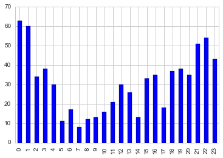

```python
crime_df.loc[crime_df['Summarized Offense Description'].isin(['ROBBERY'])]['time'].value_counts().sort_index().plot(kind='bar')
```

As you can see from above graph, most robberies are happened during 21pm to 2am, which is around midnight. Furthermore, we also need to know which incidents are most common in the evening.

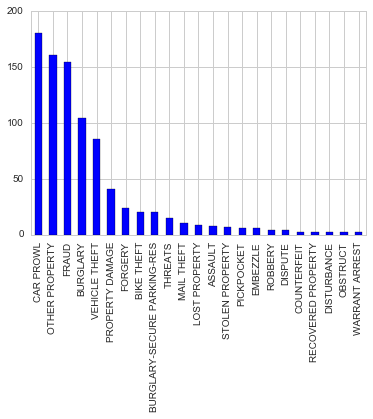

```python
crime_df.between_time('1900', '0600')['Summarized Offense Description'].value_counts().plot(kind='bar')
```

From above graph, it is obvious to see that car prowl, other property and fraud are three most common crimes during night